# P4-MPDW: Pembangkitan Proses MA(2), AR(2), dan ARMA(2,2)

# 2 Pembangkitan Model AR(2)

Model AR(2) dirumuskan sebagai berikut:
$$Y_t = \phi_1 Y_{t-1} + \phi_2 Y_{t-2} +
e_t$$
dengan $\phi_1 = 0.5$, $\phi_2 = 0.2$, dan $e_t \sim \text{WN}(0, \sigma^2)$.

### 2.0.1 Syarat Kestasioneran AR(2):

1. $\phi_1 + \phi_2 < 1 \implies 0.5 + 0.2 = 0.7 < 1$ (Terpenuhi)
2. $\phi_2 - \phi_1 < 1 \implies 0.2 - 0.5 = -0.3 < 1$ (Terpenuhi)
3. $\vert{}\phi_2\vert{} < 1 \implies \vert{}0.2\vert{} < 1$ (Terpenuhi)

Karena memenuhi ketiga syarat di atas, proses AR(2) ini dipastikan **stasioner**.

## 2.1 1. Pembangkitan Data

### 2.1.1 Menggunakan `arima.sim`

```r
set.seed(123)
n <- 300
phi1 <- 0.5
phi2 <- 0.2

ar2 <- arima.sim(list(order = c(2, 0, 0), ar = c(phi1, phi2)), n = n)
head(ar2, 10)
```

```
## Time Series:
## Start = 1
## End = 10
## Frequency = 1
##  [1] -2.9518714 -1.0047928 -0.9393975 -1.8087943  0.1615383  0.1454745
##  [7] -0.1900266  0.8292073  1.2547318  1.6147884
```

### 2.1.2 Pembangkitan Manual

```r
set.seed(123)
e <- rnorm(n, mean = 0, sd = 1)
ar2_manual <- numeric(n)

# Menetapkan nilai awal Y_1 dan Y_2
ar2_manual[1] <- e[1]
ar2_manual[2] <- phi1 * ar2_manual[1] + e[2]

# Perulangan untuk t = 3 sampai n
for (t in 3:n) {
  ar2_manual[t] <- phi1 * ar2_manual[t - 1] + phi2 * ar2_manual[t - 2] + e[t]
}

head(ar2_manual, 10)
```

```
##  [1] -0.5604756466 -0.5104153128  1.1914055285  0.5641280931  0.6496328874
##  [6]  2.1527070492  1.6671963081 -0.0009216707 -0.3538744256 -0.6227835171
```

## 2.2 Karakteristik AR(2) & Uji Kestasioneran

### 2.2.1 Plot Time Series

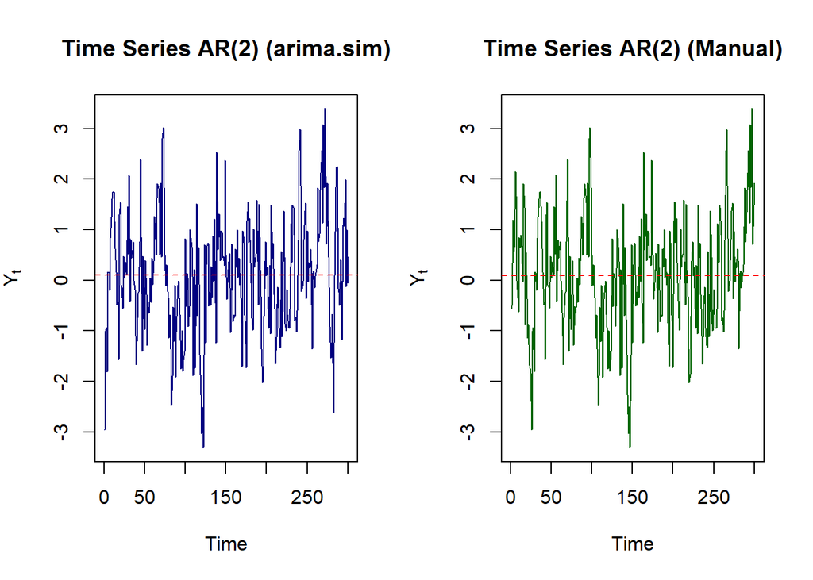

```r
par(mfrow = c(1, 2))
ts.plot(ar2, col = "navy", main = "Time Series AR(2) (arima.sim)", ylab = expression(Y[t]))
abline(h = mean(ar2), col = "red", lty = 2)

ts.plot(ar2_manual, col = "darkgreen", main = "Time Series AR(2) (Manual)", ylab = expression(Y[t]))
abline(h = mean(ar2_manual), col = "red", lty = 2)
```

```r
par(mfrow = c(1, 1))
```